# Lab7_solo

Rachael Cooper

10/18/2021

### NYTIMES: Northeast

Tasked with running sentiment analysis on several different newspapers in the Northeast, I have scraped together various different articles belonging to the New York Times newspaper. I believe this is a good representation of the Northeast region because New York Times is an established outlet that includes important information of areas outside just the New York state. Once the articles have been found and converted into the simple text files, the articles can be downloaded, piped into a data frame, the words can be tokenized, the stop words can be removed, and the counts of each word can be included in the data frame. The New York Times will serve as the corpus, then the level of positive and negative connotation associated words will be compared. Then, the patterns will be identified, and the next steps the firm can take will be clear.

Once the word frequencies have been found, the 12 articles will be compared using sentiment analysis to see if the different articles generally align or not.

Quick comparisons can be drawn by outputting the sentiment counts of each article into tables:

```r
table(sentiment_bing1$sentiment)
```

```
##
## negative positive
##       20        9
```

```r
table(sentiment_bing2$sentiment)
```

```
##
## negative positive
##       12       29
```

```r
table(sentiment_bing3$sentiment)
```

```
##
## negative positive
##       45       15
```

```r
table(sentiment_bing4$sentiment)
```

```
##
## negative positive
##       39       25
```

```r
table(sentiment_bing5$sentiment)
```

```
##
## negative positive
##       73       53
```

```r
table(sentiment_bing6$sentiment)
```

```
##
## negative positive
##       27       15
```

```r
table(sentiment_bing7$sentiment)
```

```
##
## negative positive
##       41       36
```

```r
table(sentiment_bing8$sentiment)
```

```
##
## negative positive
##       15       13
```

```r
table(sentiment_bing9$sentiment)
```

```
##
## negative positive
##       16       21
```

```r
table(sentiment_bing10$sentiment)
```

```
##
## negative positive
##       19       13
```

```r
table(sentiment_bing11$sentiment)
```

```
##
## negative positive
##       33       42
```

```r
table(sentiment_bing12$sentiment)
```

```
##
## negative positive
##       41       18
```

```r
table(sentiment_nrc1$sentiment)
```

```
##
##        anger anticipation      disgust         fear          joy     negative
##            9           12            7           19            7           20
##     positive      sadness     surprise        trust
##           34            7            6           14
```

```r
table(sentiment_nrc2$sentiment)
```

```
##
##        anger anticipation      disgust         fear          joy     negative
##           14           25           11           19           10           27
##     positive      sadness     surprise        trust
##           65           10            7           49
```

```r
table(sentiment_nrc3$sentiment)
```

```
##
##        anger anticipation      disgust         fear          joy     negative
##           14           21           15           22            9           45
##     positive      sadness     surprise        trust
##           53           12           10           38
```

```r
table(sentiment_nrc4$sentiment)
```

```
##
##        anger anticipation      disgust         fear          joy     negative
##           17           20           12           22           10           36
##     positive      sadness     surprise        trust
##           60           12            9           35
```

```r
table(sentiment_nrc5$sentiment)
```

```
##
##        anger anticipation      disgust         fear          joy     negative
##           31           43           22           46           35           64
##     positive      sadness     surprise        trust
##          112           33           19           64
```

```r
table(sentiment_nrc6$sentiment)
```

```
##
##        anger anticipation      disgust         fear          joy     negative
##            7           12            5           15            9           21
##     positive      sadness     surprise        trust
##           29           10            7           13
```

```r
table(sentiment_nrc7$sentiment)
```

```
##
##        anger anticipation      disgust         fear          joy     negative
##           16           28           13           26           17           47
##     positive      sadness     surprise        trust
##           52           21           14           26
```

```r
table(sentiment_nrc8$sentiment)
```

```
##
##        anger anticipation      disgust         fear          joy     negative
##            5           11            1            8            5           16
##     positive      sadness     surprise        trust
##           30            6            6           20
```

```r
table(sentiment_nrc9$sentiment)
```

```
##
##        anger anticipation      disgust         fear          joy     negative
##            6           14            3            9            6           16
##     positive      sadness     surprise        trust
##           51            5            5           26
```

```r
table(sentiment_nrc10$sentiment)
```

```
##
##        anger anticipation      disgust         fear          joy     negative
##            7           11            5           12            6           12
##     positive      sadness     surprise        trust
##           27            7            6           13
```

```r
table(sentiment_nrc11$sentiment)
```

```
##
##        anger anticipation      disgust         fear          joy     negative
##           12           24            8           17           16           23
##     positive      sadness     surprise        trust
##           71           11            6           47
```

```r
table(sentiment_nrc12$sentiment)
```

```
##
##        anger anticipation      disgust         fear          joy     negative
##           12           23           10           17           10           25
##     positive      sadness     surprise        trust
##           54           14            9           37
```

As shown above, the majority of the articles have both positive and negative vocabulary included. Furthermore, the vocabulary of each of the articles has a lot of anticipation and fear. This makes sense, because the Northeast includes New York city in which Climate Change has a big effect on the population. In addition, the population and the amount of industrialization of New York and the Northeast has a negative effect on the climate.

To further analyze, each of the sentiment analysis can be graphed:

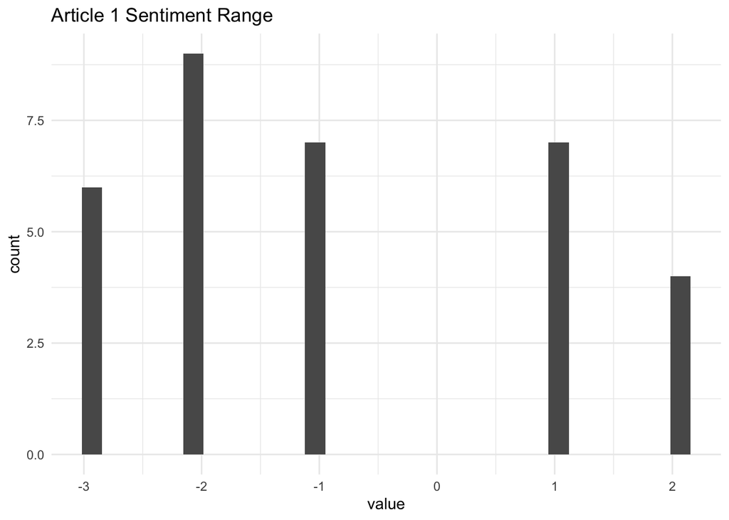

```r
# Plotting the Sentiment Analysis for Each
ggplot(data = sentiment_affin1,
       aes(x=value)
        )+
  geom_histogram()+
  ggtitle("Article 1 Sentiment Range")+
  theme_minimal()
```

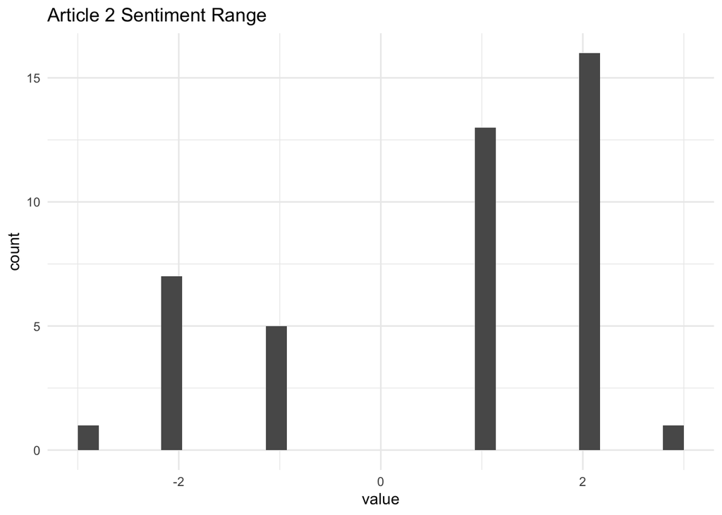

```r
ggplot(data = sentiment_affin2,
       aes(x=value)
        )+
  geom_histogram()+
  ggtitle("Article 2 Sentiment Range")+
  theme_minimal()
```

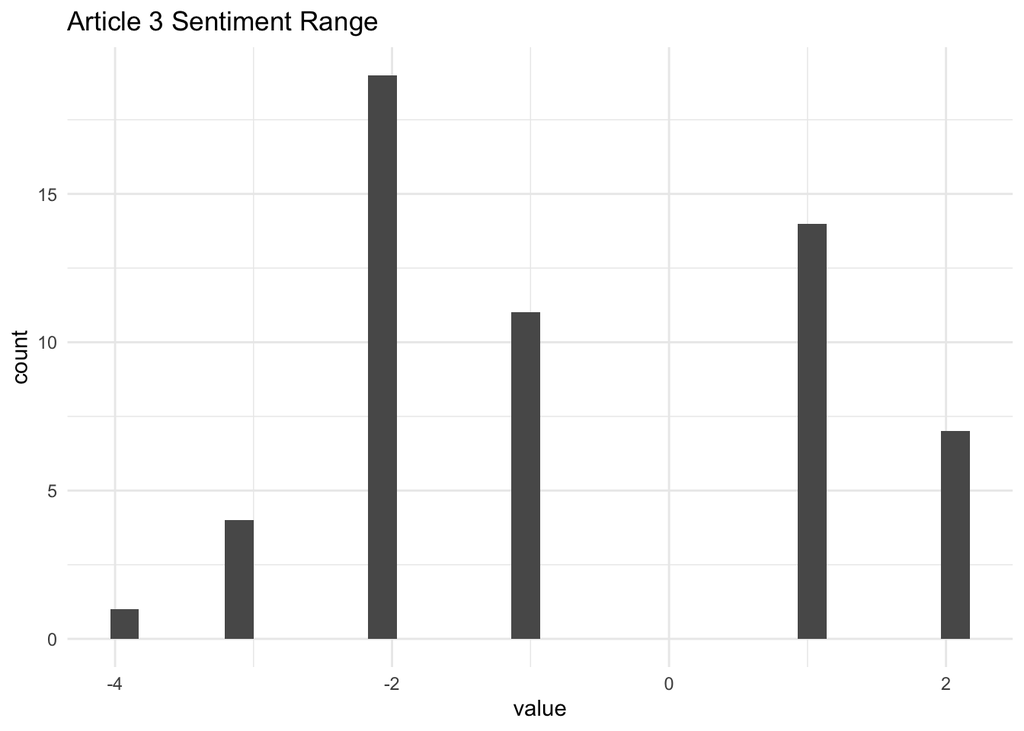

```r
ggplot(data = sentiment_affin3,
       aes(x=value)
        )+
  geom_histogram()+
  ggtitle("Article 3 Sentiment Range")+
  theme_minimal()
```

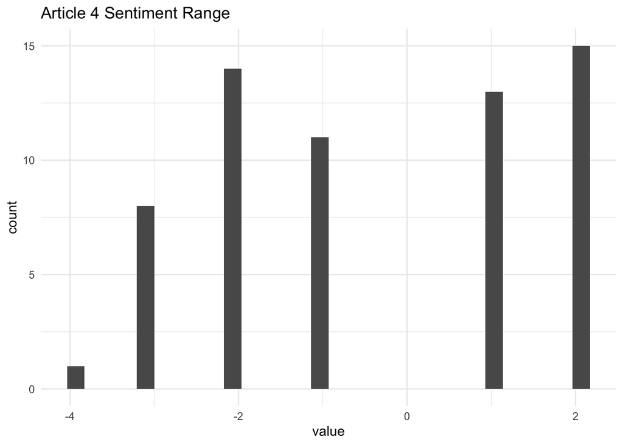

```r
ggplot(data = sentiment_affin4,
       aes(x=value)
        )+
  geom_histogram()+
  ggtitle("Article 4 Sentiment Range")+
  theme_minimal()
```

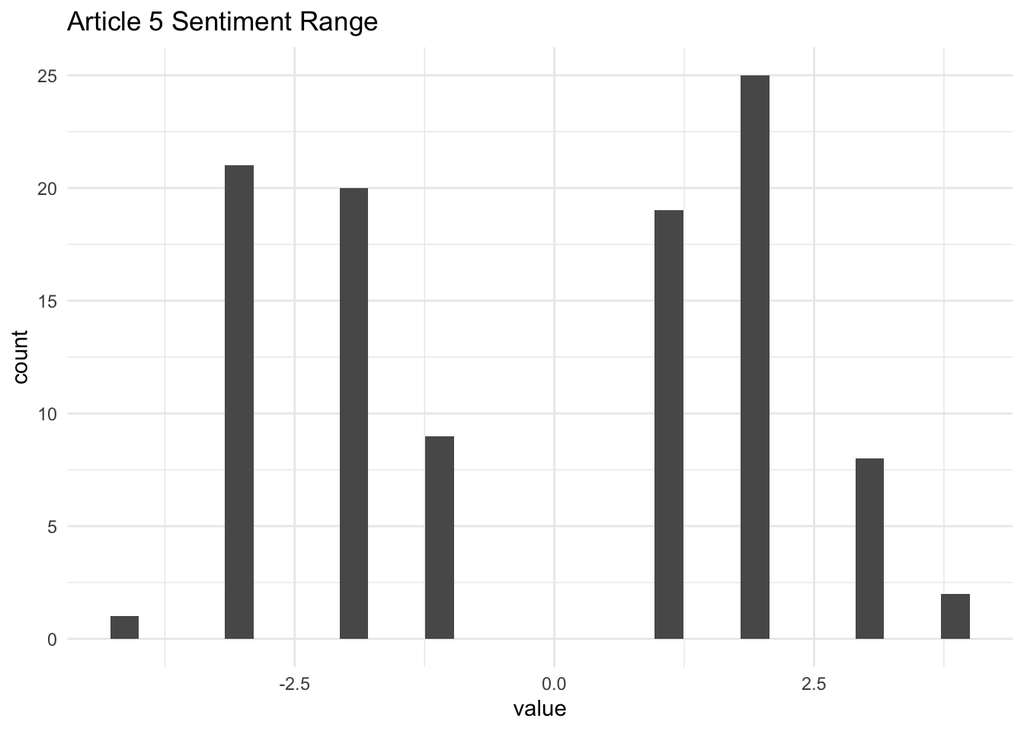

```r
ggplot(data = sentiment_affin5,
       aes(x=value)
        )+
  geom_histogram()+
  ggtitle("Article 5 Sentiment Range")+
  theme_minimal()
```

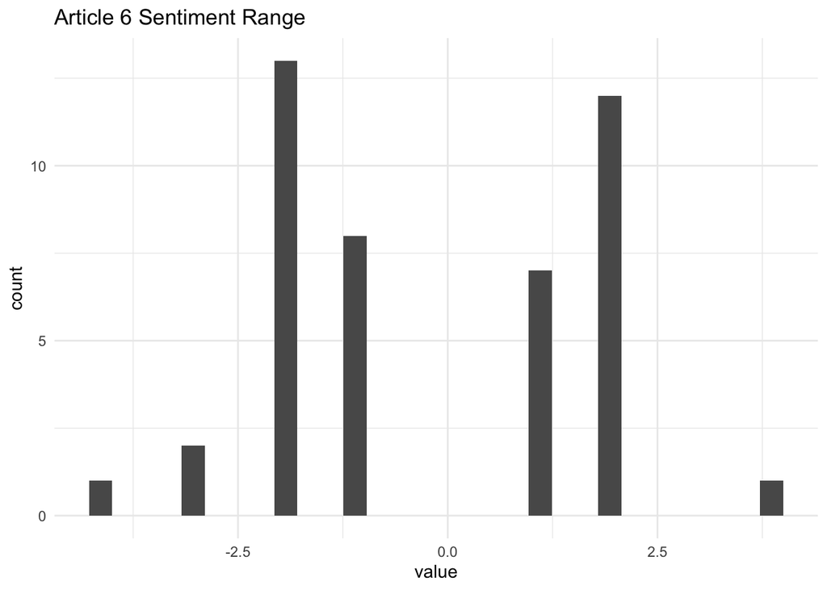

```r
ggplot(data = sentiment_affin6,
       aes(x=value)
        )+
  geom_histogram()+
  ggtitle("Article 6 Sentiment Range")+
  theme_minimal()
```

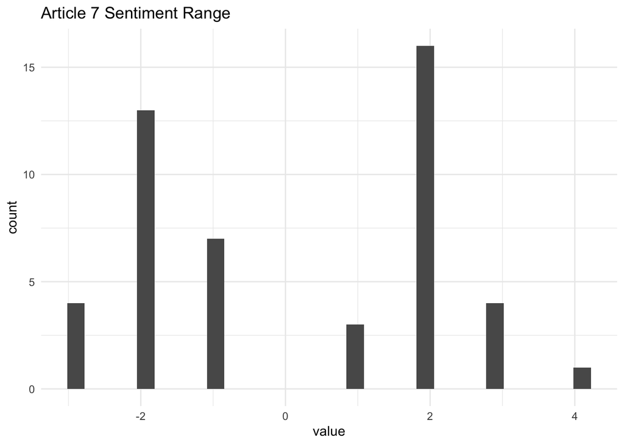

```r
ggplot(data = sentiment_affin7,
       aes(x=value)
        )+
  geom_histogram()+
  ggtitle("Article 7 Sentiment Range")+
  theme_minimal()
```

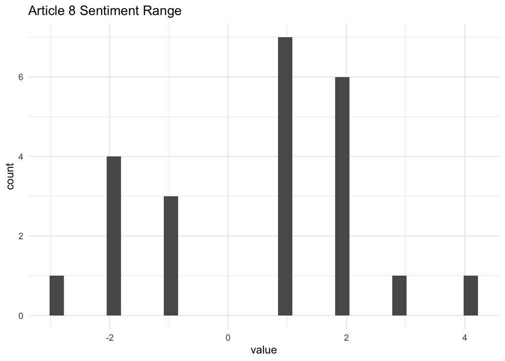

```r
ggplot(data = sentiment_affin8,
       aes(x=value)
        )+
  geom_histogram()+
  ggtitle("Article 8 Sentiment Range")+
  theme_minimal()
```

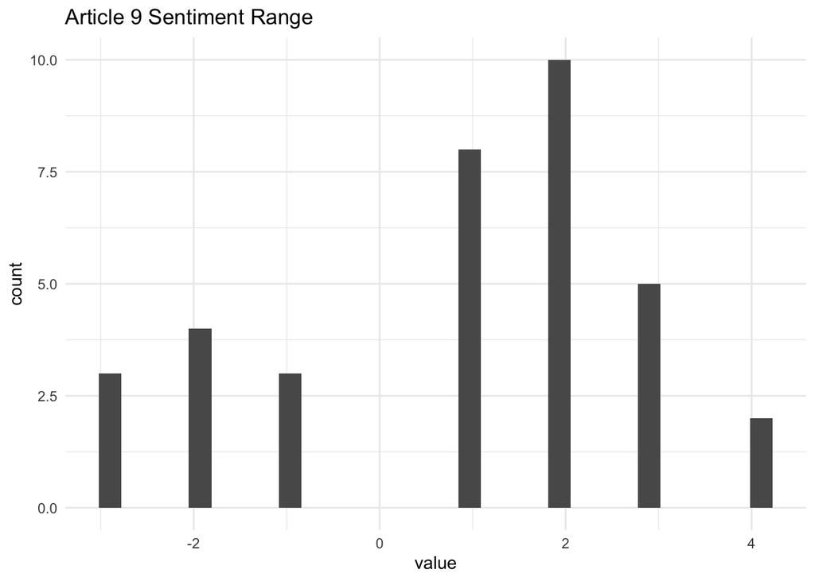

```r
ggplot(data = sentiment_affin9,
       aes(x=value)
        )+
  geom_histogram()+
  ggtitle("Article 9 Sentiment Range")+
  theme_minimal()
```

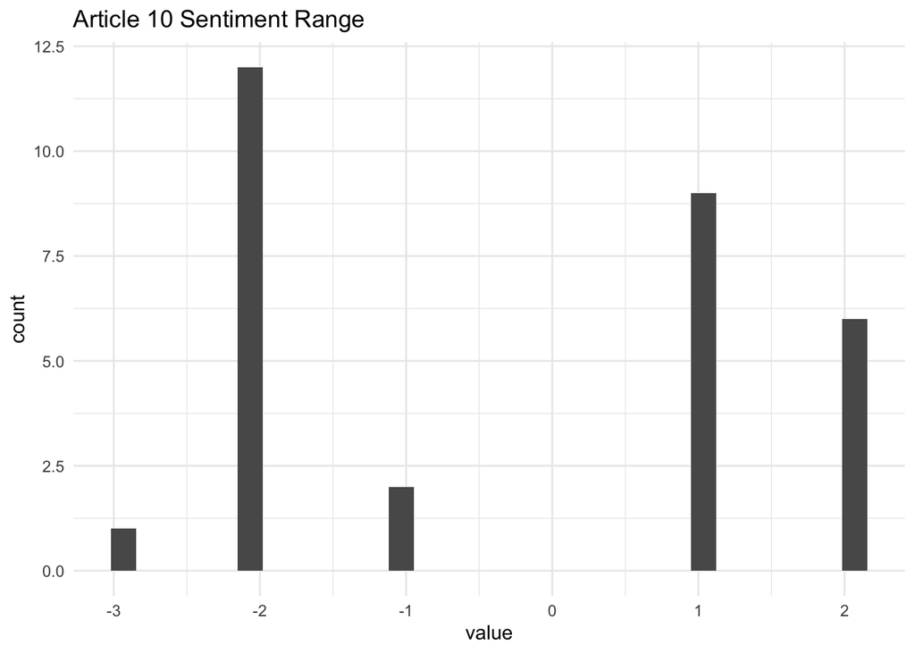

```r
ggplot(data = sentiment_affin10,
       aes(x=value)
        )+
  geom_histogram()+
  ggtitle("Article 10 Sentiment Range")+
  theme_minimal()
```

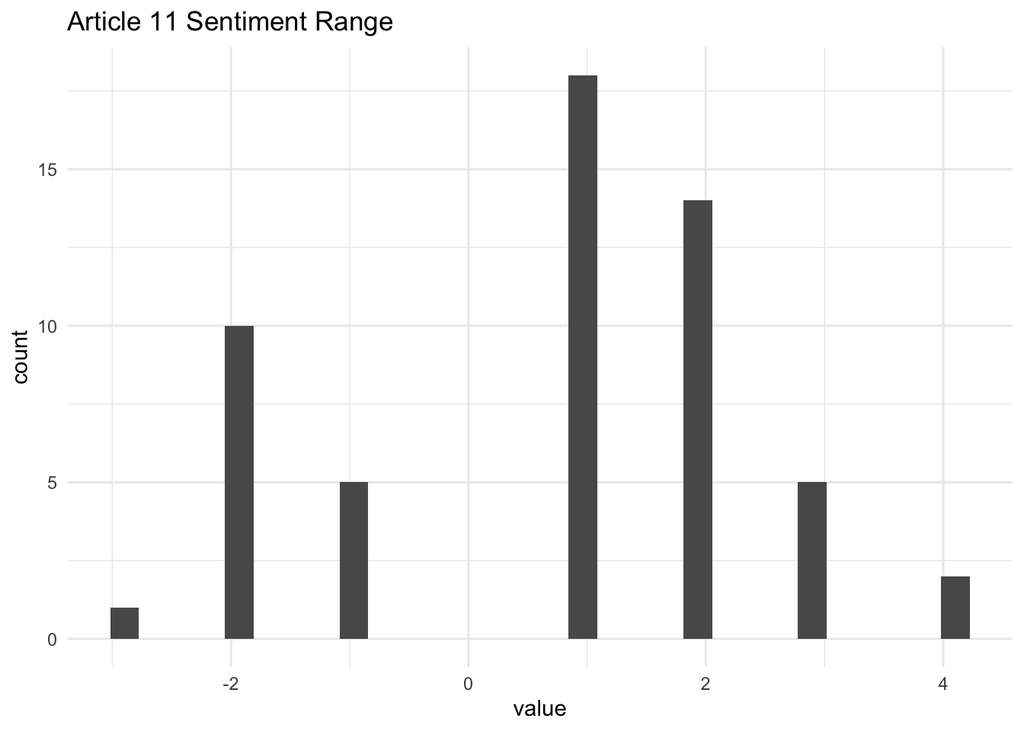

```r
ggplot(data = sentiment_affin11,
       aes(x=value)
        )+
  geom_histogram()+
  ggtitle("Article 11 Sentiment Range")+
  theme_minimal()
```

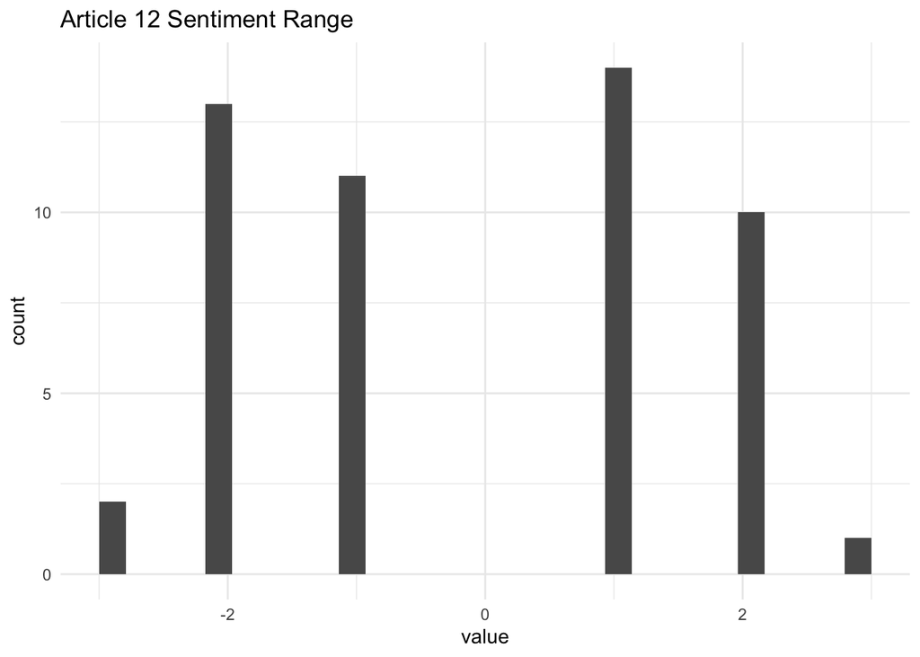

```r
ggplot(data = sentiment_affin12,
       aes(x=value)
        )+
  geom_histogram()+
  ggtitle("Article 12 Sentiment Range")+
  theme_minimal()
```

The histograms demonstrate a wide range of different sentiments between the articles. There was a lot of positive sentiment in a little less than half the articles, and a lot of negative sentiment in a little more than half the articles. The positive sentiment may stem from the hopefulness of changes and laws possibly being enacted in the region, as it is very liberal. In addition, the negative sentiment and fear could stem from the authors trying to “scare” the population into caring about the climate. Lastly, climate change itself is a negative topic in that there is little benefit that comes from it. Therefore, it is understandable, especially in the Northeast, that there is a lot of negative sentiment.

To further analyze the wording and sentiment of each of the individual articles, a cloud diagram of the most repeated words has been created for each of the articles:

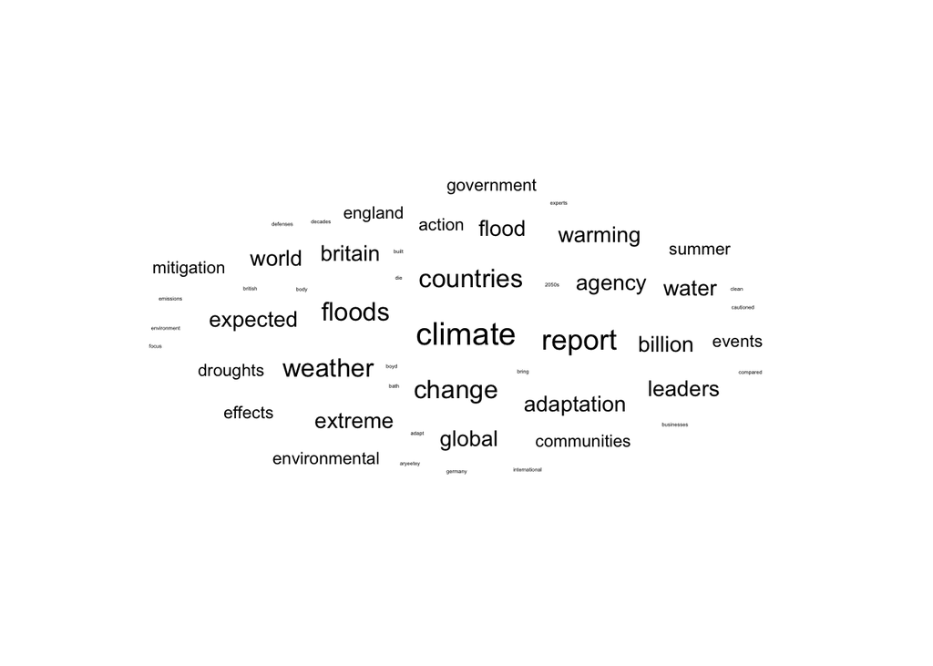

```r
#https://www.jfklibrary.org/asset-viewer/archives/TNC/TNC-172/TNC-172

# Could also do simple word clouds as we see, Trump is much more focused on the US whereas Kennedy references the "World" at a higher rate.

# below uses the ggwordcloud package for each of the speeches
set.seed(42)
ggplot(article1[1:50,], aes(label = word, size = n)
       ) +
  geom_text_wordcloud() +
  theme_minimal()
```

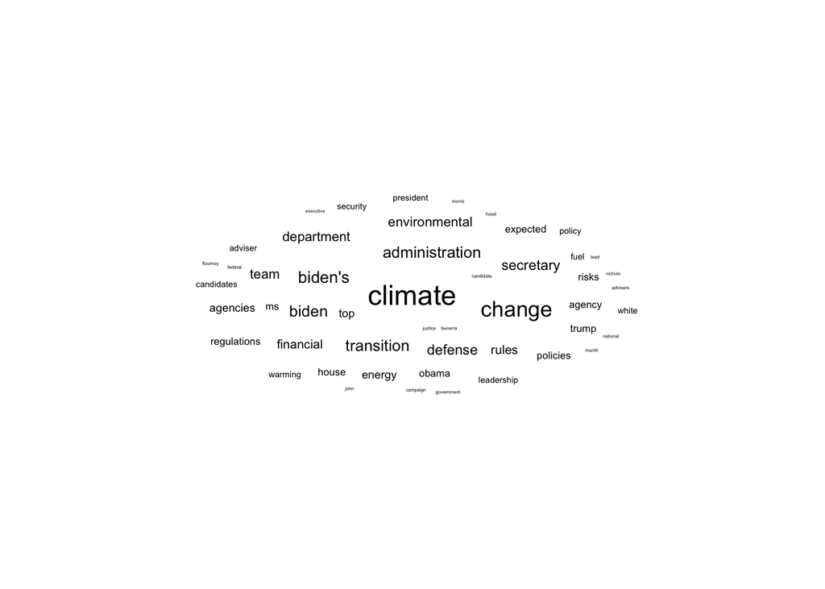

```r
ggplot(article2[1:50,], aes(label = word, size = n)
       ) +
  geom_text_wordcloud() +
  theme_minimal()
```

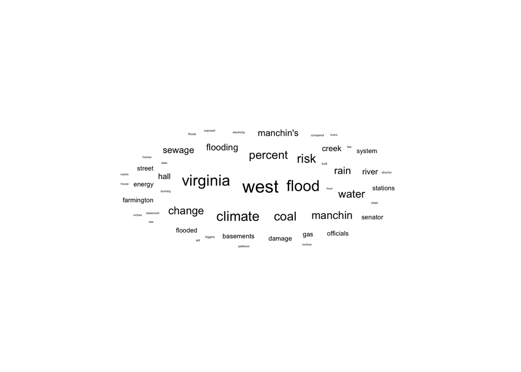

```r
ggplot(article3[1:50,], aes(label = word, size = n)
       ) +
  geom_text_wordcloud() +
  theme_minimal()
```

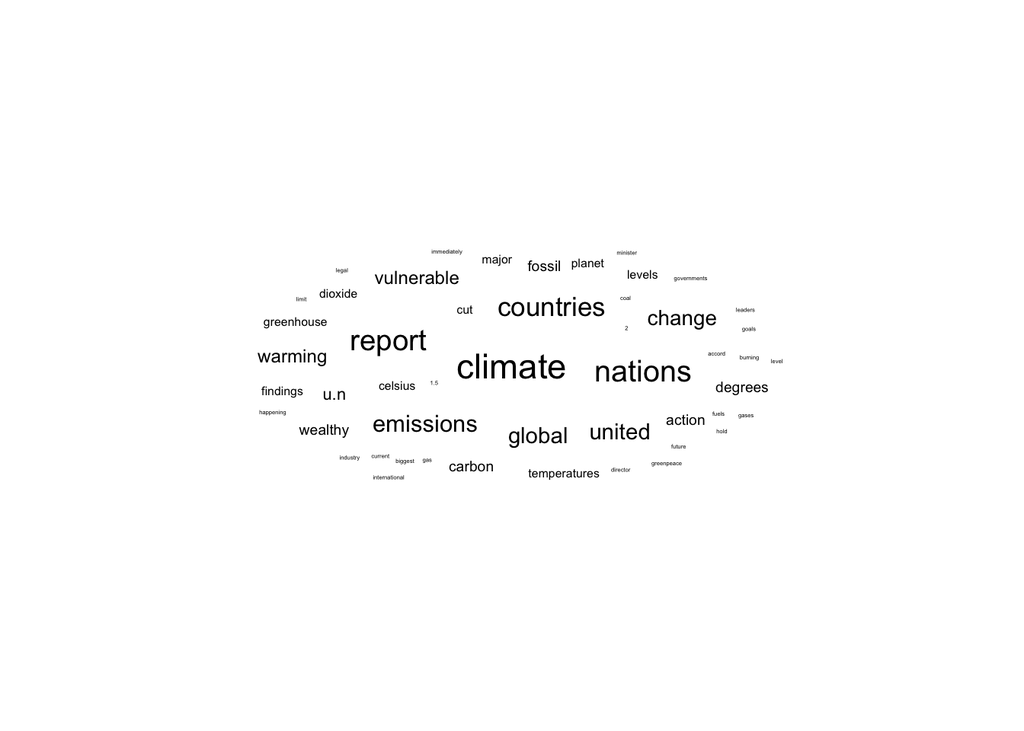

```r
ggplot(article4[1:50,], aes(label = word, size = n)
       ) +
  geom_text_wordcloud() +
  theme_minimal()
```

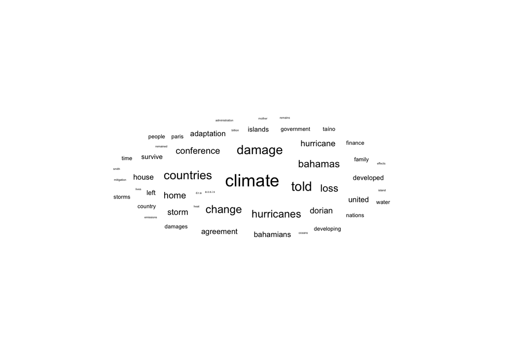

```r
ggplot(article5[1:50,], aes(label = word, size = n)
       ) +
  geom_text_wordcloud() +
  theme_minimal()
```

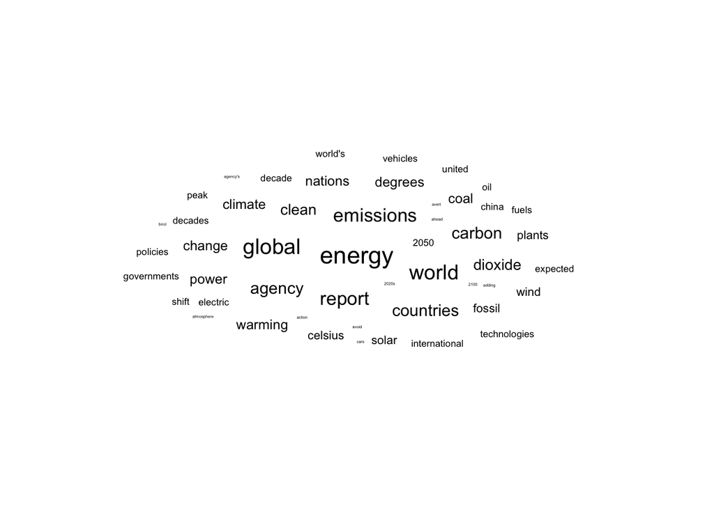

```r
ggplot(article6[1:50,], aes(label = word, size = n)
       ) +
  geom_text_wordcloud() +
  theme_minimal()
```

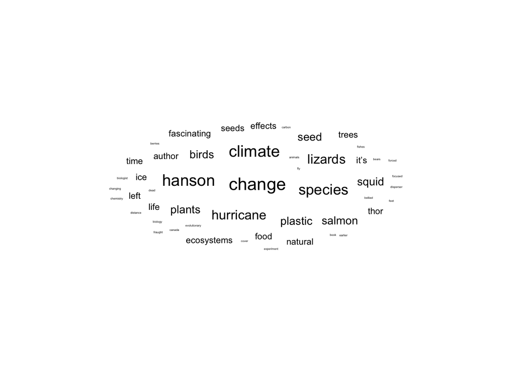

```r
ggplot(article7[1:50,], aes(label = word, size = n)
       ) +
  geom_text_wordcloud() +
  theme_minimal()
```

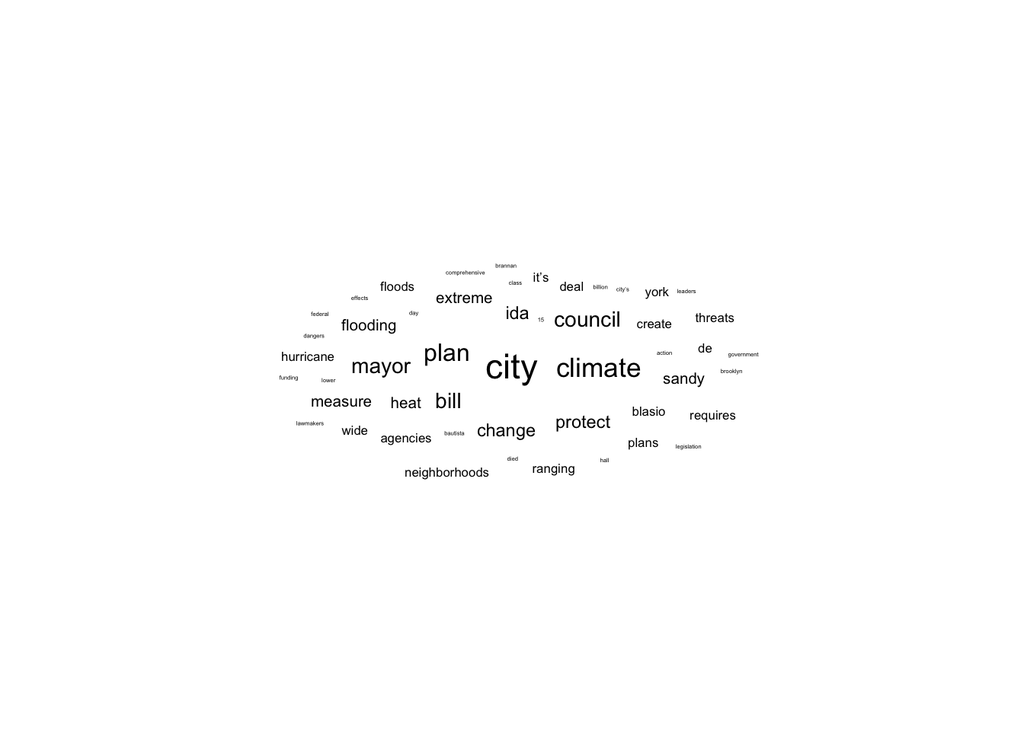

```r
ggplot(article8[1:50,], aes(label = word, size = n)
       ) +
  geom_text_wordcloud() +
  theme_minimal()
```